# Bar Plots with ggplot2

Tesfahun Tegene Boshe

06/11/2021

## Instructions

- Find interesting dataset and prepare short report (in R Markdown) which will consist:
  - short description of the dataset,
  - 4 barplots which will present interesting relationships between variables,
  - brief comments which describes obtained results.
  - Then, edit theme of the graphs and all scales of the graph and prepare publication-ready plots.

## Necessary packages

```r
requiredPackages = c("ggplot2","dplyr","tidyr")

for(i in requiredPackages){if(!require(i,character.only = TRUE)) install.packages(i)}
for(i in requiredPackages){if(!require(i,character.only = TRUE)) library(i,character.only = TRUE)}
```

## Dataset

For this task, we will analyse the English Premier League seasons 2000 - 2020. The source data is available at: https://www.kaggle.com/saife245/english-premier-league.

We will be using only the first 6 columns. The variables are explained below:

```r
Data_PLeague <- read.csv2("Premier_league.csv", sep = ",")[,c(1:6)] # only the first 6 columns
head(Data_PLeague)
```

```
##   X     Date  HomeTeam      AwayTeam FTHG FTAG
## 1 0 19/08/00  Charlton      Man City    4    0
## 2 1 19/08/00   Chelsea      West Ham    4    2
## 3 2 19/08/00  Coventry Middlesbrough    1    3
## 4 3 19/08/00     Derby   Southampton    2    2
## 5 4 19/08/00     Leeds       Everton    2    0
## 6 5 19/08/00 Leicester   Aston Villa    0    0
```

Let’s add a column for the winner team and a column for total number of columns. The value should be “draw” in case of a draw.

```r
Data_PLeague$Winner <- ifelse(Data_PLeague$FTHG>Data_PLeague$FTAG,Data_PLeague$HomeTeam, ifelse(Data_PLeague$FTHG<Data_PLeague$FTAG,Data_PLeague$AwayTeam,"Draw"))

Data_PLeague$GoalsScored <- factor(Data_PLeague$FTHG + Data_PLeague$FTAG) # define as factor
```

Let’s convert the date from a character to date format.

```r
Data_PLeague$Date <- as.Date(Data_PLeague$Date, "%d/%m/%y") # converts to date
Data_PLeague$Year <- format(Data_PLeague$Date, format = "%Y")
```

## Plots

### Plot1: Barplot of count of matches by total number of goals

#### Before edit

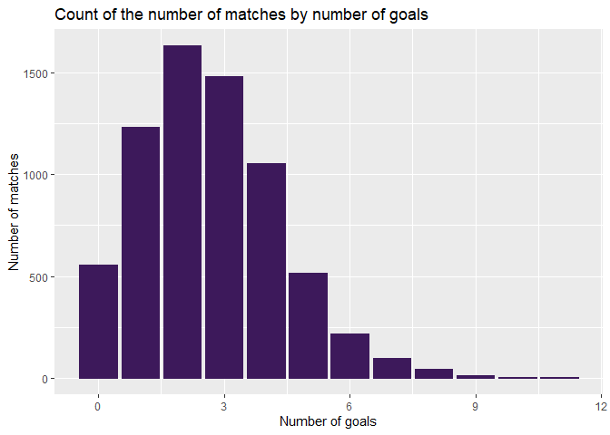

```r
p1 <- ggplot(data = Data_PLeague, aes(x = Data_PLeague$FTHG + Data_PLeague$FTAG)) +
      geom_bar(stat = "count", color = "#3d195b", fill = "#3d195b") +
      labs(x = "Number of goals",
           y = "Number of matches",
           title = "Count of the number of matches by number of goals")

p1
```

*Comments*

- Most Premier League matches experience 1-3 goals. This feeds to the general consensus that the Premier League is very defensive.

#### After Edit

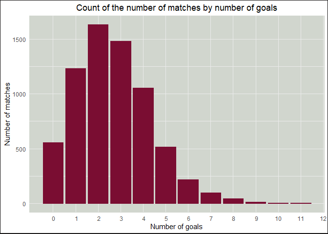

```r
p1 <- ggplot(data = Data_PLeague, aes(x = Data_PLeague$FTHG + Data_PLeague$FTAG)) +
      geom_bar(stat = "count", color = "#7a0d32", fill = "#7a0d32") +
      labs(x = "Number of goals",
           y = "Number of matches",
           title = "Count of the number of matches by number of goals") +
      theme_minimal() +
      theme(plot.title = element_text(hjust = 0.5),
            panel.background = element_rect(fill = "#d1d6ce", colour = "#d1d6ce", size = 1), #panel background
            plot.background = element_rect(colour = "#151414", size = 1) # plot background
            ) +
       scale_x_discrete(limits = c(0:12))



p1
```

### Plot2: Number of wins by team

Data preparation

```r
winsByTeam <- Data_PLeague %>%
  group_by(Winner) %>% summarize(n_wins = n())%>%
  mutate(Winner2 = reorder(Winner, desc(n_wins))) %>%
  slice_max(n_wins, n = 7) # top 6 plus draws
```

#### Before edit

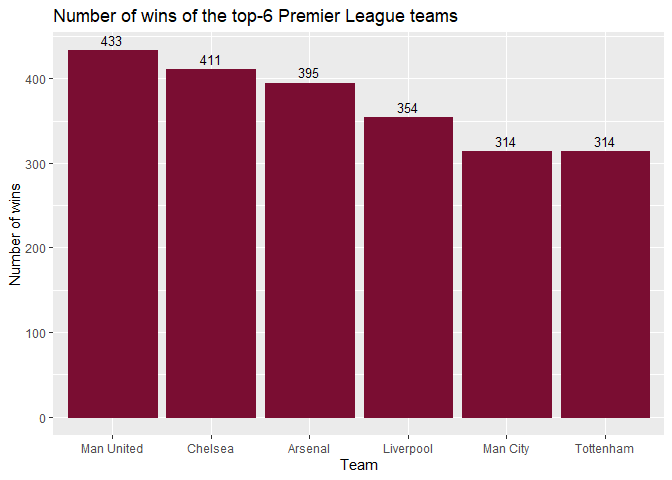

```r
p2 <- ggplot(data = winsByTeam[-1,], aes(x = Winner2, y = n_wins)) + # exclude draws
      geom_col(color = "#7a0d32", fill = "#7a0d32") + # fill with premier league brand color
      ggtitle('Number of wins of the top-6 Premier League teams') +
      xlab('Team') +
      ylab('Number of wins') +
      geom_text(aes(label = n_wins), vjust = -0.5, color = 'black',face = "bold", size = 3.5)

p2
```

*Comments*

#### After edit

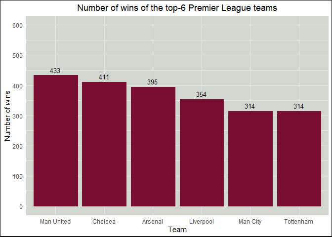

```r
p2 + theme_minimal() +
     theme(plot.title = element_text(hjust = 0.5),
          panel.background = element_rect(fill = "#d1d6ce", colour = "#d1d6ce", size = 1), #panel background
          plot.background = element_rect(colour = "#151414", size = 1) # plot background

          ) +
     scale_y_continuous(breaks = seq(0, 600, by = 100),
               limits = c(0, 600),
                )
```

### Plot3: Number of wins by Manchester United by year

#### Before edit

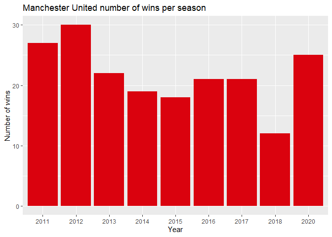

```r
Data_PLeague_MU <- Data_PLeague[Data_PLeague$Winner == "Man United" & Data_PLeague$Year >=2011 ,]# the last decade

p3 <- ggplot(data = Data_PLeague_MU, aes(x = Year)) +
      geom_bar(stat = "count",aes(y = ..count..), fill = "#DA020E")+
      labs(x = "Year",
           y = "Number of wins",
           title = "Manchester United number of wins per season")

p3
```

*Comments*

- 2012 registered the most wins for Man United. *Van Persie - Rooney* combination was the most lethal apparently. Of course defense wins games, as they say.
- The team has been falling in quality since the season 2013. *Fergie’s* departure must have had something to do with that.

#### After edit

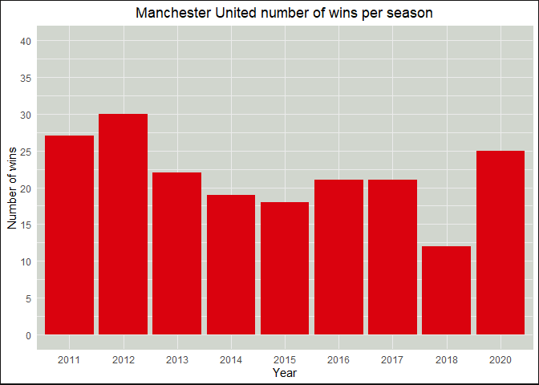

```r
p3 + theme_minimal() +
     theme(plot.title = element_text(hjust = 0.5),
          panel.background = element_rect(fill = "#d1d6ce",
                                          colour = "#d1d6ce",
                                          size = 1), #panel background
          plot.background = element_rect(colour = "#151414",
                                         size = 1) # plot background
          ) +
          scale_y_continuous(breaks = seq(0, 40, by = 5),
                     limits = c(0, 40),
                      )
```

### Plot4: Number of matches drawn per year

I believe this metric indicates how competitive the league has been across years. More number of draws indicating less competitiveness.

#### Before edit

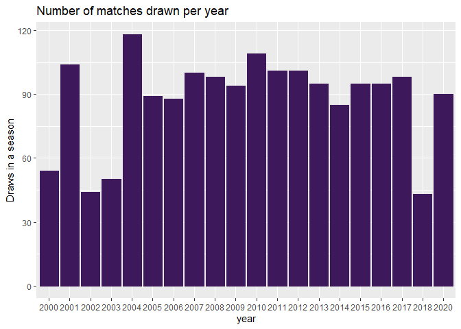

```r
p4 <- ggplot(data = Data_PLeague[Data_PLeague$Winner=="Draw",],aes(x = Year)) +
      geom_bar(stat = "count", color = "#3d195b", fill = "#3d195b") +
      labs(x = "year",
           y = "Draws in a season",
           title = "Number of matches drawn per year")

p4
```

*Comments*

#### After edit

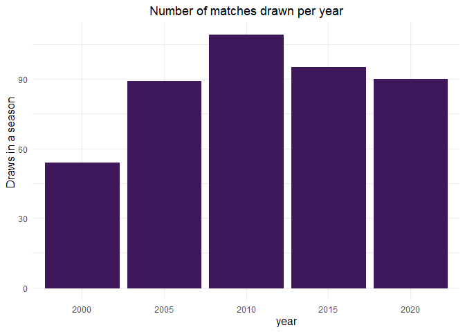

```r
p4 +
  scale_x_discrete(limits = c('2000','2005','2010','2015','2020'))+
  theme_minimal() +
  theme(plot.title = element_text(hjust = .5),

        axis.title.x  = element_text(size = 12, hjust = 0.6), # labels of the x axis
        axis.title.y  = element_text(size = 12, hjust = 0.6))
```

### Plot5: Average Number of points per game

#### Before edit

Data preparation

```r
Data_PLeague$Points_HT <- ifelse(Data_PLeague$FTHG>Data_PLeague$FTAG,3,                                                ifelse(Data_PLeague$FTHG<Data_PLeague$FTAG,0,1))

points_H_team <- Data_PLeague %>%
  group_by(HomeTeam) %>% summarize(avg_ppg = mean(Points_HT))%>%
  mutate(HomeTeam2 = reorder(HomeTeam, desc(avg_ppg))) %>%
  slice_max(avg_ppg, n = 6)
```

plot

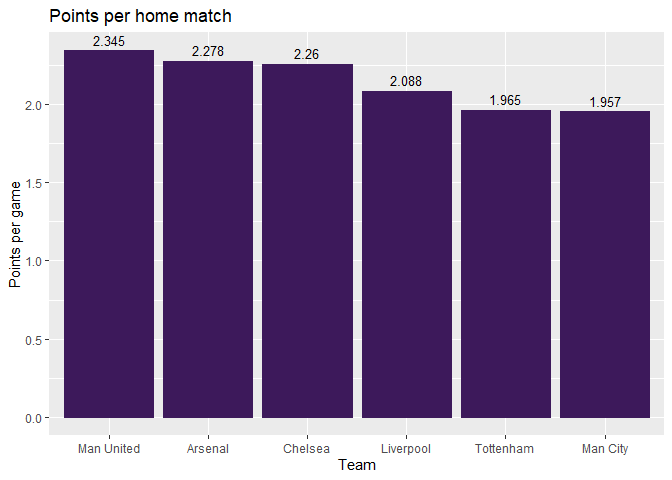

```r
p5 <- ggplot(data = points_H_team, aes(x = HomeTeam2, y = avg_ppg)) +
      geom_col(color = "#3d195b", fill = "#3d195b")+
      geom_text(aes(label = round(avg_ppg,3)), vjust = -0.5, color = 'black', size = 3.5) +
      labs(x = "Team",
               y = "Points per game",
               title = "Points per home match")

p5
```

*Comments*

- Despite the recent fall in the form, Man United remains the most successful interms of points per game. Arsenal and Chelsea follow with small margin.

#### After edit

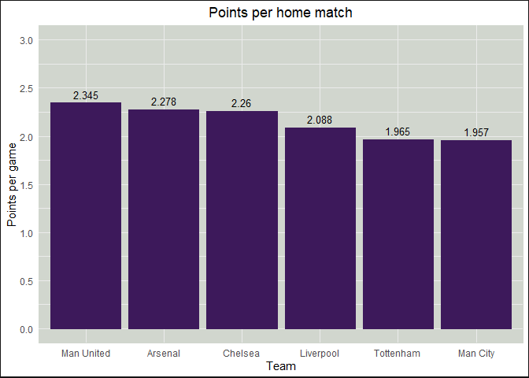

```r
p5 +
  theme_minimal() +
  theme(plot.title = element_text(hjust = 0.5),
      panel.background = element_rect(fill = "#d1d6ce",
                                      colour = "#d1d6ce",
                                      size = 1), #panel background
      plot.background = element_rect(colour = "#151414",
                                     size = 1) # plot background
      ) +
   scale_y_continuous(breaks = seq(0, 3, by = 0.5), # create more space above the plots
                      limits = c(0, 3),
                  )
```